# Trabalho Final

02 dezembro 2019

## Agenda

- Introdução
- Revisão de literatura
- Planejamento do Experimento
- Descrição dos Dados
- Análise Exploratória
- Validação das premissas
- Resultados
- Conclusão

## Introdução

### Rotas de produção de aço

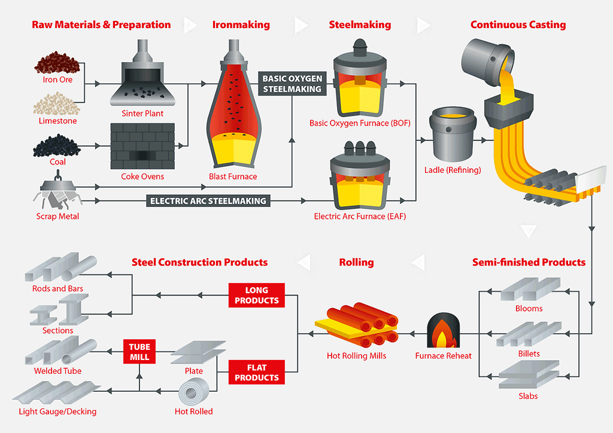

## Introdução

### Processo do Forno Elétrico

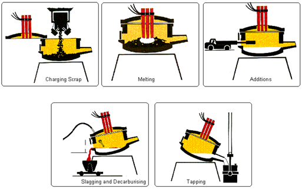

## Descrição dos Dados

- Os dados consistem no consumo de oxigênio registrado no processo de produção de aço em um forno elétrico;
- Dados - Janeiro e Outubro de 2019;
- Cada instância representa uma execução independente do processo;
- Instâncias consideradas como outliers (erros de medição, valores absurdos) foram removidas;
- Os dados foram normalizados por uma constante aleatória, por questões de confidencialidade.

| turma | material | mes | VarConsumo_Quimica |
| --- | --- | --- | --- |
| 1 | 2 | 10 | 3.506712 |
| 0 | 2 | 10 | 2.945758 |
| 1 | 2 | 10 | 3.456152 |

## Revisão de Literatura

- **Blocagem** - Usada para eliminar ruídos conhecidos e controláveis [1] - Será usada para retirar a Sazonalidade dos dados;
- **Experimento Fatorial** - Eficiente para estudo de efeitos de dois ou mais fatores [1] - Será usado para analisar os dois fatores material e turma, e a interação entre eles.

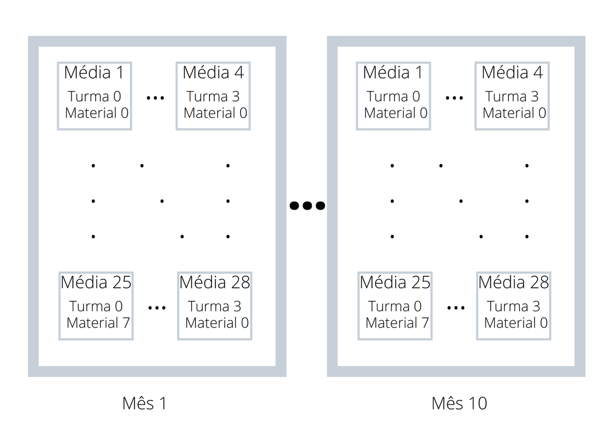

## Planejamento do Experimento

### Objetivo

O objetivo é comparar o desempenho de 4 turmas em relação ao consumo de oxigênio do processo, considerando também 9 diferentes materiais (tipos de aço) produzidos para a comparação.

Portanto, um experimento fatorial será realizado para os fatores **Turma** e **Material**. Além disso, a blocagem será realizada para o fator **Mês**, objetivando remover efeitos de sazonalidade dos dados.

Isso resulta no seguinte modelo linear [2]:

\[\begin{equation}y_{ijk} = \mu + \tau_i + \beta_j + (\tau\beta)_{ij} + \delta_k + \epsilon_{ijk} \end{equation}\]

## Planejamento do Experimento

### Hipóteses

Fator Turma: \[\begin{cases} H_0: \tau_{i} = 0, \forall i &\\H_1:\exists \tau_{i} \neq 0 \end{cases}\]

Fator Material: \[\begin{cases} H_0: \beta_{j} = 0, \forall j &\\H_1:\exists \beta_{j} \neq 0 \end{cases}\] Efeito de interação: \[\begin{cases} H_0: (\tau\beta)_{ij} = 0, \forall i,j &\\H_1:\exists (\tau\beta)_{ij} \neq 0 \end{cases}\]

## Planejamento do Experimento

### Parâmetros experimentais

- Significância desejada: \(\alpha = 0.05\).
- Mínima diferença de importância prática (padronizada): \(d^* = \delta^*/\sigma = 0.3\)
- Potência mínima desejada \(\pi = 1 - \beta = 0.8\)

## Planejamento do Experimento

### Cálculo do número de amostras

| n | ratio | phi |
| --- | --- | --- |
| 14 | 1.9430308 | 5.670 |
| 17 | 1.6103641 | 6.885 |
| 20 | 1.3678672 | 8.100 |
| 23 | 1.1846083 | 9.315 |
| 26 | 1.0419592 | 10.530 |
| 29 | 0.9281759 | 11.745 |
| 32 | 0.8355488 | 12.960 |

## Análise Exploratória

Número de amostras

```
## $turma
## turma
##    0    1    2    3
## 1062  920  988  972
##
## $material
## material
##    0    1    2    3    4    5    6    7   13
##  645  310 1200  316  196  192  651  265  167
##
## $mes
## mes
##   1   2   3   4   5   6   7   8   9  10
## 351 365 399 457 439 402 453 337 377 362
##
## $`turma:material`
##      material
## turma   0  1   2  3  4  5   6  7 13
##     0 187 92 307 89 60 29 153 78 67
##     1 113 78 310 87 57 55 154 42 24
##     2 167 68 253 71 46 56 201 81 45
##     3 178 72 330 69 33 52 143 64 31
```

## Análise Exploratória

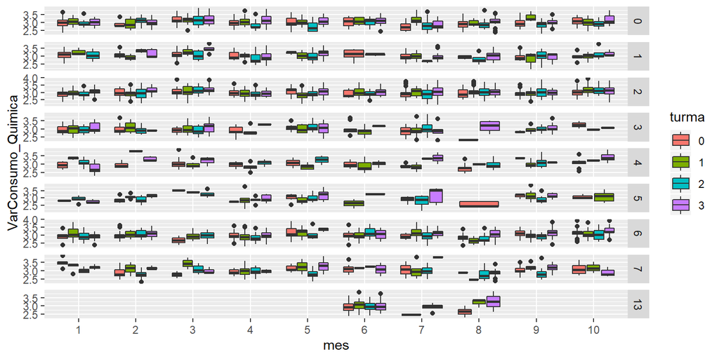

O material 13 será removido por ter sido produzio somente em alguns meses do ano.

## Análise Exploratória

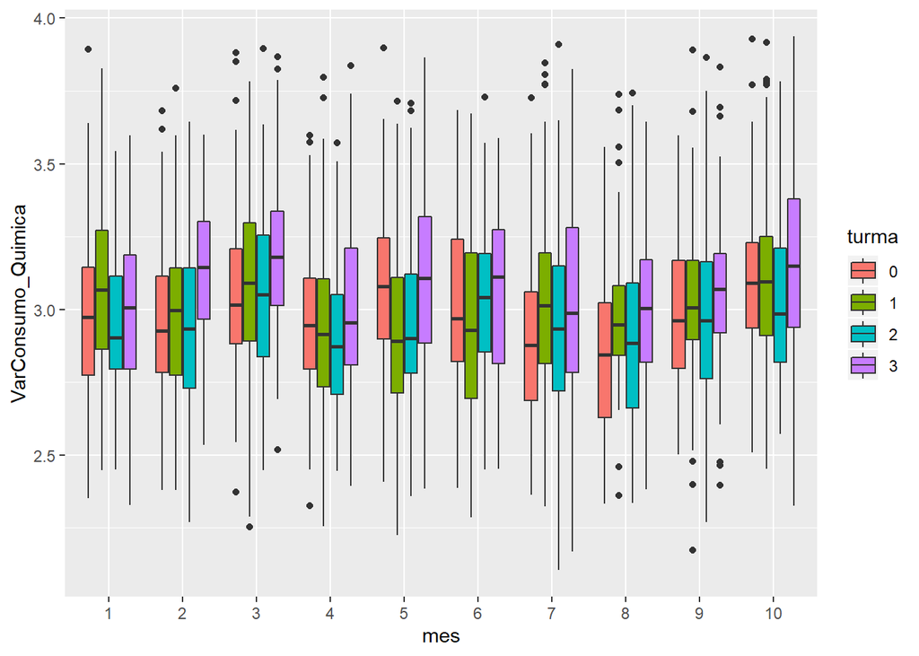

Boxplot da variável química

## Validação das premissas

### Normalidade

Teste de Shapiro-Wilk - p-value = 3.137673610^{-9}

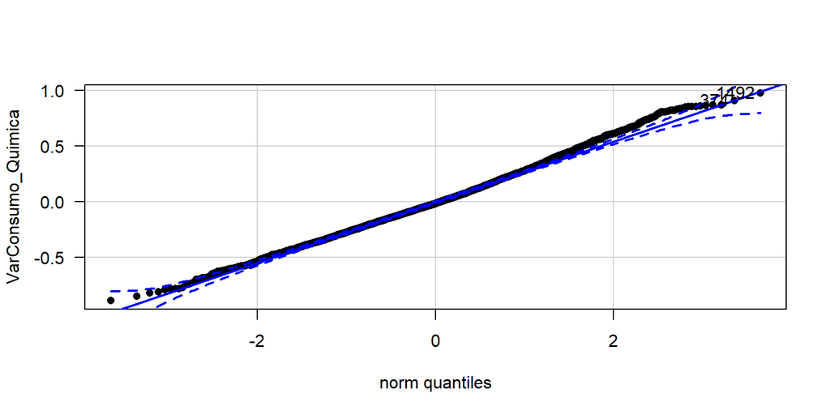

QQ plot para resíduos

## Validação das premissas

### Homocedasticidade

Teste de Fligner - p-value = 0.2476044

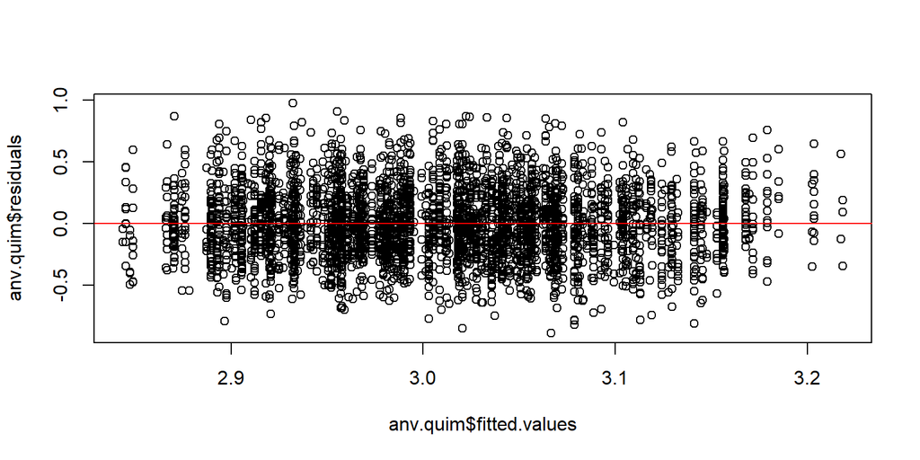

Residuals vs Fitted

## Validação das premissas

### Independência

- Cada execução do processo é independente da outra
- Existem intâncias de diferentes meses e dias, o que garante ainda mais a independência
- Pode existir certa dependência se as instâncias forem analisadas de forma sequencial. Isso só seria observado dentro de uma mesma turma.

## Resultados

```r
summary(anv.quim)
```

```
##                  Df Sum Sq Mean Sq F value  Pr(>F)
## turma             3   6.73  2.2437  27.808 < 2e-16 ***
## material          7   0.94  0.1339   1.659 0.11435
## mes               9  10.39  1.1548  14.313 < 2e-16 ***
## turma:material   21   3.26  0.1552   1.923 0.00688 **
## Residuals      3734 301.28  0.0807
## ---
## Signif. codes:  0 '***' 0.001 '**' 0.01 '*' 0.05 '.' 0.1 ' ' 1
```

## Resultados

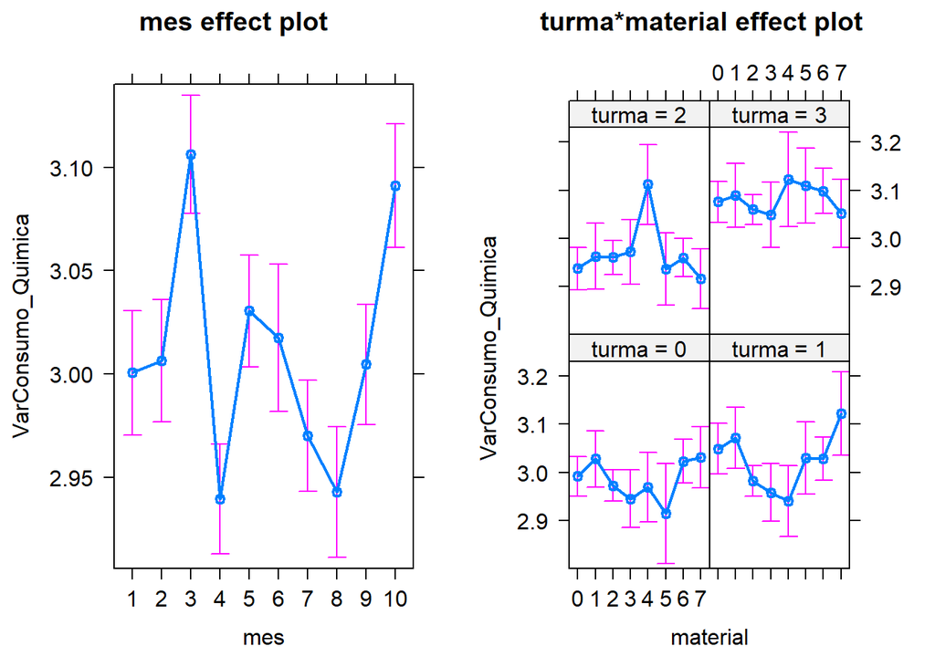

## Resultados

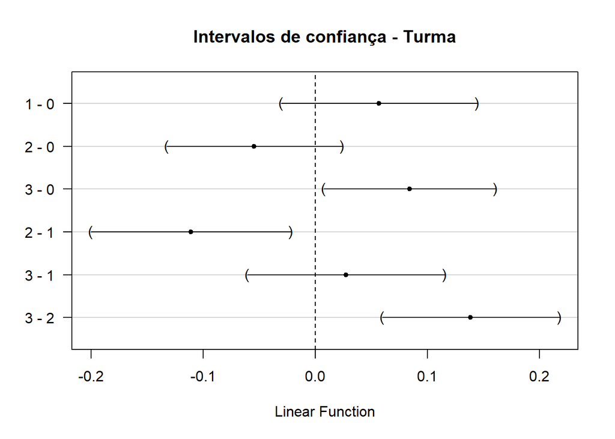

## Resultados

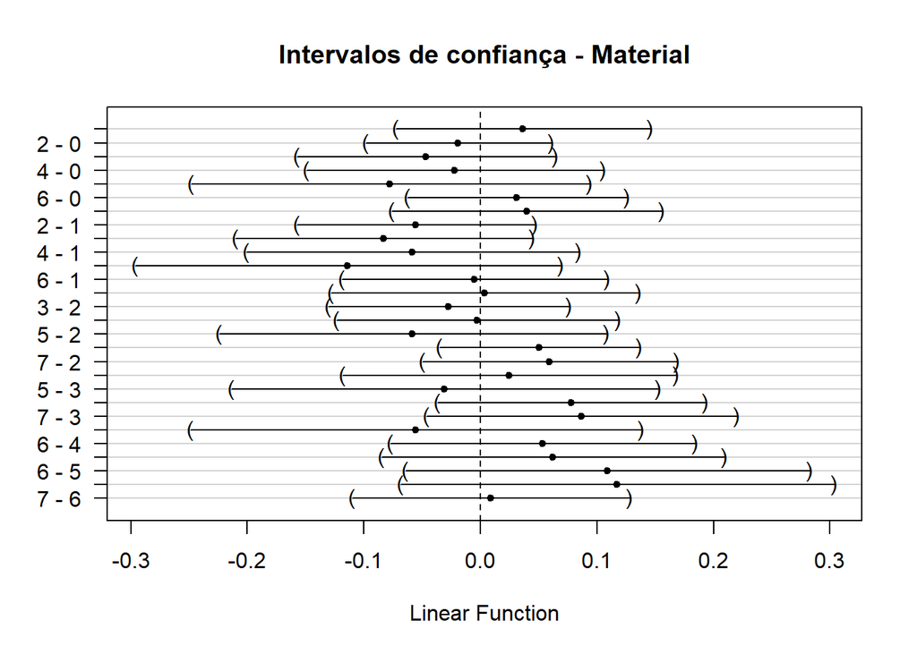

## Resultados

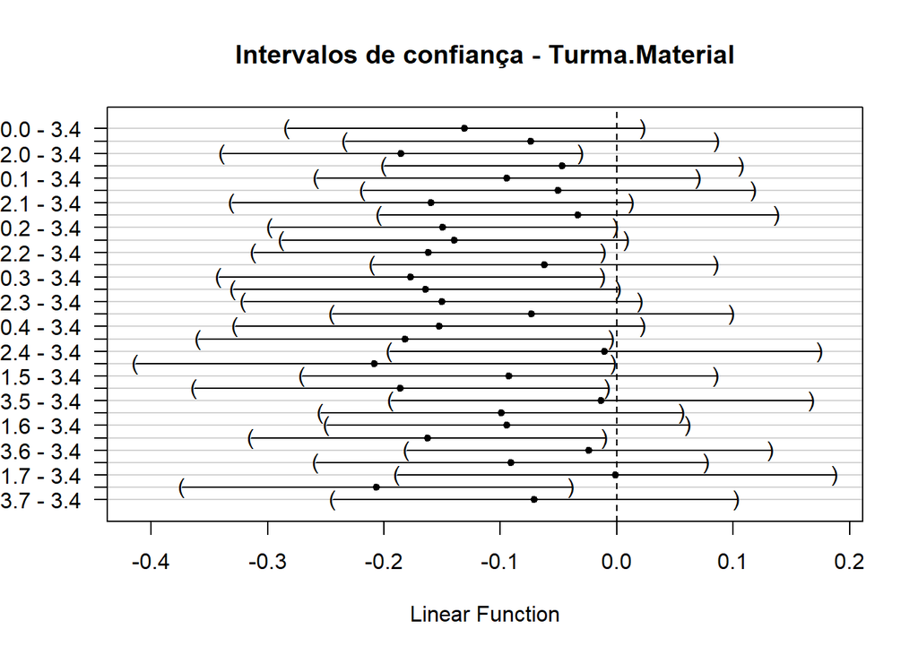

## Conclusão

- Não existem diferenças de consumo significativas ao se considerar somente o fator material
- A turma 3 possui diferença significativa em relação à 2 e 0, porém o mesmo não pode ser concluído para a 1.

## Referências

[1] D. C. Montgomery, *Design and analysis of experiments*. USA: John Wiley &#38; Sons, Inc., 2006.

[2] D. C. Montgomery and G. C. Runger, *Applied statistics and probability for engineers, (with cd)*. John Wiley & Sons, 2007.